# Introduction

In this homework case-study, we will be learning how to apply Principal Component Analysis on numerai dataset. The dataset is of multivariate characteristic, has 502732 rows and 51 columns. The dataset contain the following variables:

1. Column 1-50 correspond to the features of X or input data, data type: continuous numeric
2. Column 51 correspond to targets fulfilled by Bernie, 1 being Yes (target fulfilled) and 0 being No (Target not fulfilled), data type: discrete continuous.

Now, let's proceed towards our PCA analysis on this dataset.

## Step 1: Importing the libraries

Like we did in our classroom case-study, the first step is to import the libraries that we require for this analysis.

```python
import numpy as np
import pandas as pd
import math
from matplotlib import pyplot as plt
from sklearn.preprocessing import StandardScaler
import seaborn as sns # We will visualize the correlation plots with this library
from sklearn.decomposition import PCA
```

## Step 2: Importing the dataset

We can import the dataset using the read_csv() function that is found in the pandas library. Though the dataset is in .csv format, we can use the read_csv() function to go ahead with this. The read_csv() function takes in the path name of the file along with extension of the file and returns a dataframe. We will then get the dataframe saved in a variable called as df and inspect if we have got the right data by looking at its head or the top 5 rows of the dataset.

```python
df = pd.read_csv("numerai_training_data.csv")
df.head()
```

|  | feature1 | feature2 | feature3 | feature4 | feature5 | feature6 | feature7 | feature8 | feature9 | feature10 | ... | feature42 | feature43 | feature44 | feature45 | feature46 | feature47 | feature48 | feature49 | feature50 | target_bernie |
| --- | --- | --- | --- | --- | --- | --- | --- | --- | --- | --- | --- | --- | --- | --- | --- | --- | --- | --- | --- | --- | --- |
| 0 | 0.54836 | 0.31077 | 0.37524 | 0.49490 | 0.53217 | 0.48388 | 0.50220 | 0.59506 | 0.55422 | 0.48578 | ... | 0.32205 | 0.53407 | 0.46254 | 0.56658 | 0.46022 | 0.63760 | 0.55239 | 0.64054 | 0.52182 | 1 |
| 1 | 0.34712 | 0.40275 | 0.42747 | 0.44006 | 0.47866 | 0.44055 | 0.59182 | 0.68856 | 0.56543 | 0.57715 | ... | 0.46215 | 0.48303 | 0.35919 | 0.58709 | 0.55369 | 0.64628 | 0.46029 | 0.62941 | 0.55010 | 1 |
| 2 | 0.50871 | 0.48639 | 0.47544 | 0.40306 | 0.53436 | 0.64028 | 0.51420 | 0.63232 | 0.62101 | 0.48065 | ... | 0.50243 | 0.51624 | 0.48028 | 0.73195 | 0.42444 | 0.43228 | 0.40596 | 0.54731 | 0.39061 | 0 |
| 3 | 0.61363 | 0.40268 | 0.53779 | 0.37045 | 0.58711 | 0.59900 | 0.62428 | 0.73602 | 0.43887 | 0.28383 | ... | 0.54347 | 0.46995 | 0.60385 | 0.56471 | 0.51203 | 0.35597 | 0.53878 | 0.47776 | 0.36835 | 0 |
| 4 | 0.30704 | 0.47273 | 0.54495 | 0.48692 | 0.47348 | 0.34695 | 0.41506 | 0.61225 | 0.56853 | 0.44104 | ... | 0.54050 | 0.39448 | 0.29495 | 0.61935 | 0.45651 | 0.53768 | 0.46431 | 0.49482 | 0.60452 | 1 |

5 rows × 51 columns

As can be seen, we have got the right data. Let's now start with the next step, Data Cleaning.

## Step 3: Data Cleaning

First, by using the describe function, we will see if there are any missing values in the dataset or not. If there are any missing values, we will do missing value imputation, if not we will move to the next step.

```python
df.describe()
```

|  | feature1 | feature2 | feature3 | feature4 | feature5 | feature6 | feature7 | feature8 | feature9 | feature10 | ... | feature42 | feature43 | feature44 | feature45 | feature46 | feature47 | feature48 | feature49 | feature50 | target_bernie |
| --- | --- | --- | --- | --- | --- | --- | --- | --- | --- | --- | --- | --- | --- | --- | --- | --- | --- | --- | --- | --- | --- |
| count | 502732.000000 | 502732.000000 | 502732.000000 | 502732.000000 | 502732.000000 | 502732.000000 | 502732.000000 | 502732.000000 | 502732.000000 | 502732.000000 | ... | 502732.000000 | 502732.000000 | 502732.000000 | 502732.000000 | 502732.000000 | 502732.000000 | 502732.000000 | 502732.000000 | 502732.000000 | 502732.000000 |
| mean | 0.464556 | 0.455349 | 0.481495 | 0.443951 | 0.509341 | 0.487672 | 0.527147 | 0.558786 | 0.522584 | 0.467633 | ... | 0.499177 | 0.483734 | 0.487759 | 0.533082 | 0.531598 | 0.521866 | 0.522082 | 0.497006 | 0.523742 | 0.499918 |
| std | 0.131996 | 0.100119 | 0.116514 | 0.109570 | 0.112263 | 0.115142 | 0.123103 | 0.115907 | 0.103687 | 0.115763 | ... | 0.121436 | 0.120519 | 0.136137 | 0.118067 | 0.107027 | 0.112586 | 0.115974 | 0.109166 | 0.106865 | 0.500000 |
| min | 0.000000 | 0.000000 | 0.000000 | 0.000140 | 0.000000 | 0.000000 | 0.012970 | 0.019400 | 0.022150 | 0.000000 | ... | 0.000000 | 0.031500 | 0.000000 | 0.000000 | 0.042000 | 0.006810 | 0.000920 | 0.000000 | 0.000000 | 0.000000 |
| 25% | 0.371850 | 0.388450 | 0.401670 | 0.370500 | 0.435150 | 0.408290 | 0.444280 | 0.482040 | 0.454780 | 0.388060 | ... | 0.417360 | 0.398170 | 0.393470 | 0.453990 | 0.457200 | 0.445720 | 0.442660 | 0.423650 | 0.452430 | 0.000000 |
| 50% | 0.463720 | 0.454715 | 0.479100 | 0.443310 | 0.512390 | 0.486830 | 0.529835 | 0.562790 | 0.525270 | 0.463440 | ... | 0.499285 | 0.479060 | 0.484710 | 0.537100 | 0.529360 | 0.521630 | 0.521200 | 0.498090 | 0.524600 | 0.000000 |
| 75% | 0.555810 | 0.521620 | 0.559240 | 0.516250 | 0.586410 | 0.565500 | 0.612662 | 0.639700 | 0.592780 | 0.543260 | ... | 0.580820 | 0.564560 | 0.579060 | 0.615313 | 0.603970 | 0.597840 | 0.600840 | 0.572020 | 0.595760 | 1.000000 |
| max | 0.990850 | 0.904370 | 0.974100 | 0.974990 | 0.992520 | 0.998750 | 1.000000 | 0.995880 | 1.000000 | 0.990150 | ... | 1.000000 | 0.993630 | 1.000000 | 1.000000 | 0.985080 | 1.000000 | 1.000000 | 0.931190 | 1.000000 | 1.000000 |

8 rows × 51 columns

Since there are no missing values in the dataset, let's now look at the correlation plot.

## Step 4: Correlation Analysis

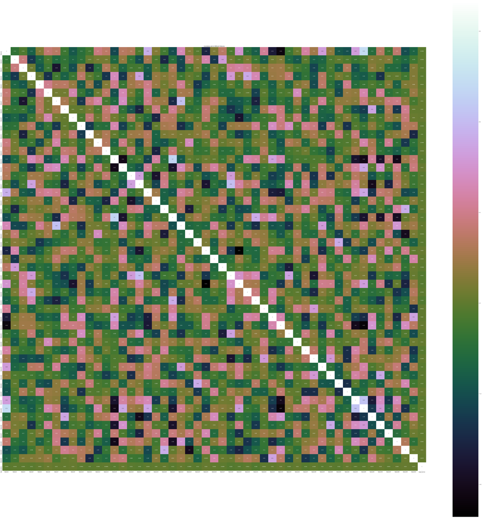

```python
correlation_mat = df.corr()
plt.figure(figsize=(100,100))
sns.heatmap(correlation_mat, vmax = 1, square = True, annot=True, cmap = 'cubehelix')
plt.title('Correlation plot of different features')
```

```python
cols = df.columns.tolist()
cols
```

```
['feature1',
 'feature2',
 'feature3',
 'feature4',
 'feature5',
 'feature6',
 'feature7',
 'feature8',
 'feature9',
 'feature10',
 'feature11',
 'feature12',
 'feature13',
 'feature14',
 'feature15',
 'feature16',
 'feature17',
 'feature18',
 'feature19',
 'feature20',
 'feature21',
 'feature22',
 'feature23',
 'feature24',
 'feature25',
 'feature26',
 'feature27',
 'feature28',
 'feature29',
 'feature30',
 'feature31',
 'feature32',
 'feature33',
 'feature34',
 'feature35',
 'feature36',
 'feature37',
 'feature38',
 'feature39',
 'feature40',
 'feature41',
 'feature42',
 'feature43',
 'feature44',
 'feature45',
 'feature46',
 'feature47',
 'feature48',
 'feature49',
 'feature50',
 'target_bernie']
```

```python
cols.insert(0, cols.pop(cols.index('target_bernie')))
cols
```

```
['target_bernie',
 'feature1',
 'feature2',
 'feature3',
 'feature4',
 'feature5',
 'feature6',
 'feature7',
 'feature8',
 'feature9',
 'feature10',
 'feature11',
 'feature12',
 'feature13',
 'feature14',
 'feature15',
 'feature16',
 'feature17',
 'feature18',
 'feature19',
 'feature20',
 'feature21',
 'feature22',
 'feature23',
 'feature24',
 'feature25',
 'feature26',
 'feature27',
 'feature28',
 'feature29',
 'feature30',
 'feature31',
 'feature32',
 'feature33',
 'feature34',
 'feature35',
 'feature36',
 'feature37',
 'feature38',
 'feature39',
 'feature40',
 'feature41',
 'feature42',
 'feature43',
 'feature44',
 'feature45',
 'feature46',
 'feature47',
 'feature48',
 'feature49',
 'feature50']
```

```python
df = df.reindex(columns=cols)
X = df.iloc[:, 1:51].values
y = df.iloc[:, 0].values
X
```

```
array([[0.54836, 0.31077, 0.37524, ..., 0.55239, 0.64054, 0.52182],
       [0.34712, 0.40275, 0.42747, ..., 0.46029, 0.62941, 0.5501 ],
       [0.50871, 0.48639, 0.47544, ..., 0.40596, 0.54731, 0.39061],
       ...,
       [0.59956, 0.53761, 0.46091, ..., 0.73485, 0.35128, 0.51475],
       [0.38474, 0.53465, 0.4783 , ..., 0.52453, 0.50027, 0.67738],
       [0.4339 , 0.48851, 0.50105, ..., 0.58938, 0.46715, 0.45706]])
```

```python
y
```

```
array([1, 1, 0, ..., 0, 0, 0], dtype=int64)
```

```python
np.shape(X)
```

```
(502732, 50)
```

## Step 5: Data Standardization

Standardization is defined as transforming the dataset in such a way that it has zero mean and standard deviation equal to one. We do this by using StandardScaler() function of scikitLearn.

```python
X_std = StandardScaler().fit_transform(X)
```

## Step 6: Covariance Matrix

After standardization, let's proceed to find the covariance between all the features of X so that we can then proceed towards calculating the eigen-pairs.

```python
mean_vec = np.mean(X_std, axis=0)
cov_mat = (X_std - mean_vec).T.dot((X_std - mean_vec)) / (X_std.shape[0]-1)
print('Covariance matrix \n%s' %cov_mat)
```

```
Covariance matrix
[[ 1.00000199 -0.11582828 -0.04059541 ...  0.23432899 -0.30559243
  -0.2028127 ]
 [-0.11582828  1.00000199  0.26892277 ... -0.13255613 -0.18840756
  -0.07820872]
 [-0.04059541  0.26892277  1.00000199 ... -0.17759028 -0.27553518
   0.07668792]
 ...
 [ 0.23432899 -0.13255613 -0.17759028 ...  1.00000199  0.19039727
  -0.13255812]
 [-0.30559243 -0.18840756 -0.27553518 ...  0.19039727  1.00000199
   0.02054456]
 [-0.2028127  -0.07820872  0.07668792 ... -0.13255812  0.02054456
   1.00000199]]
```

Let's also test it by using numpy.

```python
print('NumPy covariance matrix: \n%s' %np.cov(X_std.T))
```

```
NumPy covariance matrix:
[[ 1.00000199 -0.11582828 -0.04059541 ...  0.23432899 -0.30559243
  -0.2028127 ]
 [-0.11582828  1.00000199  0.26892277 ... -0.13255613 -0.18840756
  -0.07820872]
 [-0.04059541  0.26892277  1.00000199 ... -0.17759028 -0.27553518
   0.07668792]
 ...
 [ 0.23432899 -0.13255613 -0.17759028 ...  1.00000199  0.19039727
  -0.13255812]
 [-0.30559243 -0.18840756 -0.27553518 ...  0.19039727  1.00000199
   0.02054456]
 [-0.2028127  -0.07820872  0.07668792 ... -0.13255812  0.02054456
   1.00000199]]
```

Let's now have a look at covariance matrix by means of heatmap.

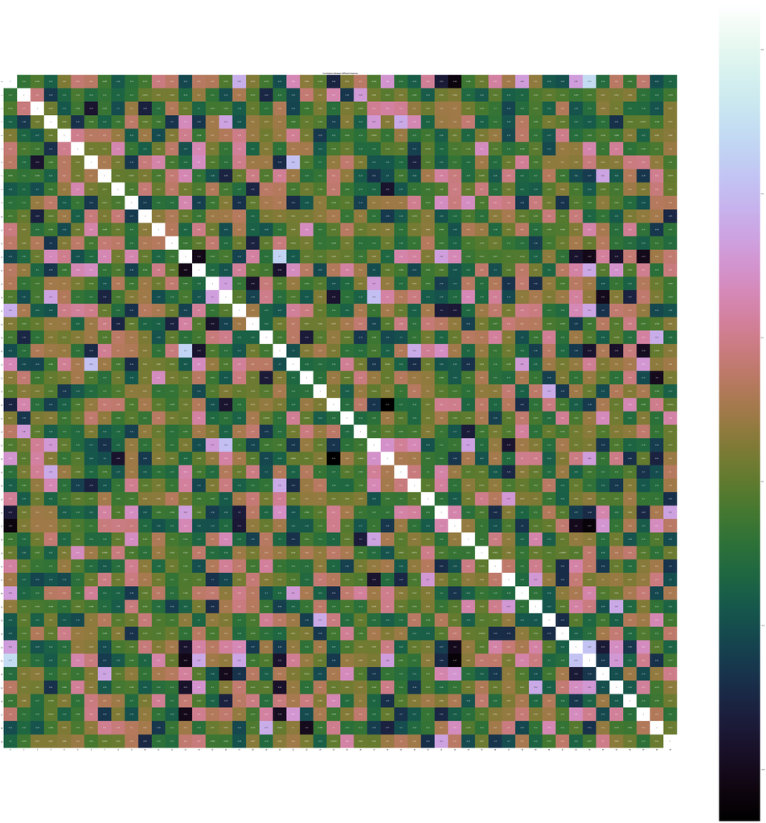

```python
plt.figure(figsize=(100,100))
sns.heatmap(cov_mat, vmax=1, square=True,annot=True,cmap='cubehelix')

plt.title('Correlation between different features')
```

which is approximately the same as that of correlation matrix that we had calculated above.

## Step 7: Eigen Decomposition of the Covariance Matrix

Eigenvectors give us the direction of the principal components and eigenvalues let us know about the amount of variance defined by that principal component. This gives us an idea about the new feature subspaces.

```python
eig_vals, eig_vecs = np.linalg.eig(cov_mat)

print('Eigenvectors \n%s' %eig_vecs)
print('\nEigenvalues \n%s' %eig_vals)
```

```
Eigenvectors
[[-0.26400424 -0.01919885 -0.05612708 ...  0.02972743  0.03842704
   0.04755177]
 [ 0.01152278 -0.03448211 -0.10258573 ... -0.09691918  0.07035052
   0.06276284]
 [ 0.07673222  0.15195091 -0.16378677 ... -0.03314601  0.09563474
  -0.08376994]
 ...
 [-0.20326508 -0.04419827  0.15717343 ...  0.01216857 -0.30573905
   0.03468571]
 [ 0.1104802  -0.09242092  0.29992742 ... -0.07884958  0.01548499
  -0.20023436]
 [ 0.09289684 -0.0203194  -0.21527493 ...  0.23185599  0.00276065
  -0.11432102]]

Eigenvalues
[7.57621951 5.70623875 4.75518746 3.84532339 3.5542462  3.15102753
 2.9242514  2.4004729  2.26090264 2.0657605  1.55701269 1.43978205
 1.34585408 1.09257397 0.82894278 0.75171029 0.69079664 0.55207449
 0.45641791 0.3944455  0.33350574 0.29602899 0.2262202  0.21457297
 0.17232378 0.15309002 0.13913513 0.13089508 0.10162565 0.09066213
 0.0892364  0.07777729 0.07189302 0.00831138 0.0099087  0.01308579
 0.01476694 0.01878796 0.01994832 0.0239363  0.02661154 0.0296892
 0.03479718 0.03872307 0.04149931 0.0451218  0.06178496 0.0583313
 0.0552211  0.05336751]
```

## Step 8: Selecting Principal Components

The eigen vectors having the least eigenvalues hold very less information and can be eliminated altogether. Let's arrange the eigenvalues in descending order to go ahead with this analysis.

```python
# Make a list of (eigenvalue, eigenvector) tuples
eig_pairs = [(np.abs(eig_vals[i]), eig_vecs[:,i]) for i in range(len(eig_vals))]

# Sort the (eigenvalue, eigenvector) tuples from high to low
eig_pairs.sort(key=lambda x: x[0], reverse=True)

print('Eigenvalues in descending order:')
for i in eig_pairs:
    print(i[0])
```

```
Eigenvalues in descending order:
7.57621951183969
5.706238753023179
4.755187462069007
3.8453233873164736
3.554246201420862
3.1510275329495636
2.9242514010423317
2.400472896418965
2.2609026427994214
2.0657604976697344
1.5570126904241948
1.4397820471553517
1.345854078857164
1.092573973745466
0.8289427756260618
0.7517102907780231
0.6907966370642817
0.5520744875845466
0.4564179132538871
0.3944455001336904
0.33350574367640345
0.29602899488749596
0.22622019782623792
0.21457297161953898
0.1723237785419724
0.15309002292207943
0.13913512903905287
0.1308950803503357
0.10162565002101608
0.09066212995492473
0.0892363997172855
0.07777729153858265
0.07189301854956265
0.06178496319348957
0.05833130118159376
0.05522109626603763
0.053367513761391774
0.04512180010299397
0.041499308504650695
0.03872307229278563
0.03479718150442112
0.029689202736107614
0.026611540020724772
0.023936303280996
0.01994831788847591
0.01878795936067141
0.014766942397860104
0.01308579167375999
0.009908695395704546
0.008311377389152752
```

Now, we will make use of Explained variance chart to choose the number of principal components.

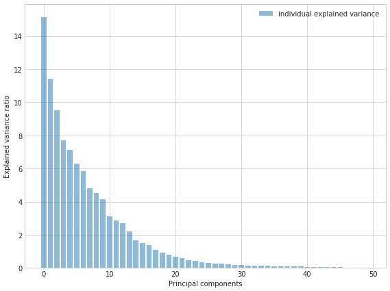

```python
tot = sum(eig_vals)
var_exp = [(i / tot)*100 for i in sorted(eig_vals, reverse=True)]
cum_var_exp = np.cumsum(var_exp)

with plt.style.context('seaborn-whitegrid'):
    plt.figure(figsize=(8, 6))

    plt.bar(range(50), var_exp, alpha=0.5, align='center',
            label='individual explained variance')
    plt.ylabel('Explained variance ratio')
    plt.xlabel('Principal components')
    plt.legend(loc='best')
    plt.tight_layout()
```

The plot above shows that the first principal component shows 15.2% of explained variance ratio, second shows 11.5% of explained variance, third one shows 9.5%, after fourteenth principal component, the explained variance is less than 2%.

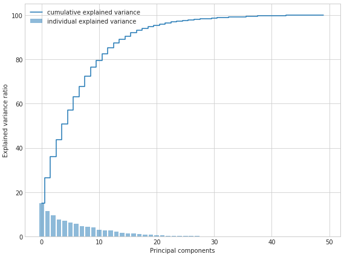

```python
with plt.style.context('seaborn-whitegrid'):
    plt.figure(figsize=(8, 6))

    plt.bar(range(50), var_exp, alpha=0.5, align='center',
            label='individual explained variance')
    plt.step(range(50), cum_var_exp, where='mid',
             label='cumulative explained variance')
    plt.ylabel('Explained variance ratio')
    plt.xlabel('Principal components')
    plt.legend(loc='best')
    plt.tight_layout()
```

The above plot shows that about 95% of the variance is explained till 20th principal component. So, we will choose first twenty principal components.

## Step 9: The Projection Matrix

Since 95% of the info is explained upto 20th principal component, let's obtain the projection matrix using first twenty components. Here, we are reducing the 50-dimensional feature space to 20-dimensional subspace. The Projection Matrix will be 50 x 20 matrix.

```python
matrix_w = np.hstack((eig_pairs[0][1].reshape(50,1),
                      eig_pairs[1][1].reshape(50,1),
                      eig_pairs[2][1].reshape(50,1),
                      eig_pairs[3][1].reshape(50,1),
                      eig_pairs[4][1].reshape(50,1),
                      eig_pairs[5][1].reshape(50,1),
                      eig_pairs[6][1].reshape(50,1),
                      eig_pairs[7][1].reshape(50,1),
                      eig_pairs[8][1].reshape(50,1),
                      eig_pairs[9][1].reshape(50,1),
                      eig_pairs[10][1].reshape(50,1),
                      eig_pairs[11][1].reshape(50,1),
                      eig_pairs[12][1].reshape(50,1),
                      eig_pairs[13][1].reshape(50,1),
                      eig_pairs[14][1].reshape(50,1),
                      eig_pairs[15][1].reshape(50,1),
                      eig_pairs[16][1].reshape(50,1),
                      eig_pairs[17][1].reshape(50,1),
                      eig_pairs[18][1].reshape(50,1),
                      eig_pairs[19][1].reshape(50,1)
                    ))
print('Matrix W:\n', matrix_w)
```

```
Matrix W:
 [[-2.64004236e-01 -1.91988531e-02 -5.61270840e-02  1.10705639e-01
   9.44798353e-02 -1.17845433e-01 -1.89965158e-01 -9.15725359e-02
   1.54080385e-01 -4.51922806e-02 -5.53313561e-02  1.45321910e-01
   2.95982256e-02 -5.53685767e-02  1.10670071e-01  1.27515761e-01
  -5.13007853e-02  1.37174771e-01  3.80384430e-02 -1.30093379e-01]
 [ 1.15227760e-02 -3.44821103e-02 -1.02585728e-01  2.00438193e-01
  -3.14429918e-02  2.86369788e-01  2.98022661e-01  4.41233203e-02
   2.10325065e-01  6.96673394e-02 -1.67459595e-01  9.42882842e-02
  -9.84269231e-02  6.95186082e-02  3.93648085e-04 -3.48041706e-02
  -6.50286848e-02  1.06734021e-01  4.15646974e-03  2.79252860e-02]
 [ 7.67322235e-02  1.51950906e-01 -1.63786772e-01  8.09114552e-02
  -1.38576970e-01  1.21921916e-01 -1.11318938e-02 -1.02615867e-01
   2.28202935e-01 -1.11466153e-01  3.61792004e-01  1.62835734e-01
  -1.25932057e-01  8.22304393e-02  6.34619887e-02 -1.01894056e-01
   1.25546545e-01  2.21618987e-01  1.50100365e-01 -2.41397614e-01]
 [ 1.00790402e-01  2.29750247e-01 -4.87802916e-02 -1.37254586e-01
   1.18377735e-01 -2.48537302e-01  7.74668576e-02  2.31206182e-02
  -2.09215709e-01  1.13836347e-01  5.97025865e-02  4.67301171e-02
  -3.98908414e-02  6.88118675e-02  3.22602961e-01  5.50110088e-02
  -1.18619137e-01  1.12244922e-02  9.27989088e-02  2.39554493e-02]
 [-6.35700993e-03 -3.89046765e-02 -6.28920788e-02 -2.24896069e-01
   1.80105832e-01 -7.42373367e-02 -1.57170257e-01  3.82250387e-01
   1.90245205e-01 -5.95640715e-02 -1.29056291e-01 -7.68640448e-02
   2.75180967e-02 -4.97645741e-02 -2.07563320e-01 -1.06567320e-01
  -1.68112562e-02  9.42738018e-03  1.37905290e-02  8.90017277e-02]
 [-1.10704235e-01 -9.68842812e-02 -5.12784474e-02 -1.09205690e-01
  -9.31907005e-02  2.12936009e-01 -2.51176669e-01  1.91861124e-01
  -1.48454617e-02 -2.61983083e-01 -1.27864949e-01  6.77833535e-02
  -3.99337706e-02 -7.93252889e-02  1.87515280e-01  8.59564633e-02
  -1.09872444e-01 -2.00654293e-01 -2.19014557e-01 -6.41593201e-02]
 [-1.24287001e-01 -2.33628690e-01  8.23641730e-03 -1.63487487e-01
   7.69518571e-02 -1.50904309e-01  4.82593406e-02  1.27866578e-02
  -1.46643786e-01  1.69877351e-01 -7.65619842e-02  6.64907229e-02
  -2.09385042e-01 -1.01823910e-02 -1.73574661e-01  1.66575510e-01
  -5.52381553e-02  3.37065536e-01 -1.17769177e-01  9.52501815e-02]
 [ 1.54598595e-01 -2.09515164e-01  2.49595247e-02  4.90354092e-03
   1.50158877e-02 -8.91458197e-02 -2.12850473e-01 -1.95948754e-02
   1.76186114e-01  5.87286056e-02 -1.01318027e-01 -1.15070758e-01
  -2.93180629e-01 -1.20411058e-03 -6.85041012e-02  2.01306530e-01
```

[output cut: 196 more lines]

```
 [-2.03265080e-01 -4.41982697e-02  1.57173430e-01 -1.19904285e-01
  -6.72189695e-02 -1.16989070e-01  2.56738925e-01 -1.07096498e-01
  -1.43169936e-02 -3.78696029e-02  1.99351514e-01  6.88630136e-02
   1.41732434e-01 -5.47604441e-02  2.45917005e-01 -1.35376465e-01
  -1.76899368e-02  5.58330338e-03  5.88510826e-02 -1.50026580e-01]
 [ 1.10480197e-01 -9.24209224e-02  2.99927420e-01 -1.70229929e-01
  -9.84845682e-02 -8.32047357e-02  4.83445753e-02  9.38153227e-03
   1.23805331e-01 -2.28085883e-02 -1.63193082e-01  3.46431758e-02
   9.41161813e-02  1.24066562e-01 -7.93100095e-03  6.06363808e-02
   1.62017746e-01  5.40024689e-02 -2.33528285e-01 -1.50136534e-01]
 [ 9.28968372e-02 -2.03194016e-02 -2.15274934e-01 -1.61662502e-01
  -1.43076185e-01 -7.44274130e-02  5.70033528e-02 -1.04392795e-01
  -7.96330333e-02 -3.04673491e-01 -2.54237968e-01 -4.66075453e-02
   1.83406454e-01 -1.14339493e-01 -1.60020773e-01 -7.59878203e-02
  -4.12857686e-04 -1.12427325e-02  2.38461420e-01  6.96687634e-03]]
```

## Step 10: Projection onto the new feature space

Y = X * W Here, Y is the new feature space X is the standardized input data W is the projection matrix

```python
Y = X_std.dot(matrix_w)
Y
```

```
array([[ 0.1971204 , -1.14436196,  2.21233348, ..., -0.33570865,
         0.16442499,  0.15494415],
       [ 1.47495804, -0.27007439,  2.6964821 , ..., -0.32794652,
         1.59211799,  0.02430379],
       [ 1.34505658, -1.46024953,  0.1382432 , ...,  1.0533616 ,
        -1.34715612, -0.06058095],
       ...,
       [-3.21083618,  2.2800469 , -2.85119111, ..., -0.35989804,
         1.18450855,  0.44241554],
       [ 2.25363446, -3.55171628, -2.69789114, ...,  0.61800287,
         0.37309599, -1.19452159],
       [ 1.49791668, -1.93669552,  0.62625988, ...,  0.423677  ,
        -0.39078036, -0.5010631 ]])
```

# PCA in ScikitLearn

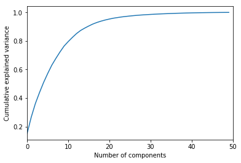

```python
from sklearn.decomposition import PCA
pca = PCA().fit(X_std)
plt.plot(np.cumsum(pca.explained_variance_ratio_))
plt.xlim(0,50,1)
plt.xlabel('Number of components')
plt.ylabel('Cumulative explained variance')
```

```python
from sklearn.decomposition import PCA
sklearn_pca = PCA(n_components=20)
Y_sklearn = sklearn_pca.fit_transform(X_std)
```

```python
print(Y_sklearn)
```

```
[[-0.1971204  -1.14436196  2.21233347 ... -0.33568059  0.16432297
  -0.15545219]
 [-1.47495804 -0.27007439  2.69648211 ... -0.32791829  1.59187138
  -0.02479958]
 [-1.34505658 -1.46024953  0.13824321 ...  1.05345406 -1.34749741
   0.06016903]
 ...
 [ 3.21083617  2.28004691 -2.85119109 ... -0.35984579  1.18427939
  -0.4420081 ]
 [-2.25363446 -3.55171629 -2.69789115 ...  0.61804525  0.37293943
   1.19440231]
 [-1.49791668 -1.93669552  0.6262599  ...  0.4237381  -0.39105068
   0.50055579]]
```

which is the same as that of the matrix we calculated without using scikitLearn.

```python
Y_sklearn.shape
```

```
(502732, 20)
```

Thus, out of the 50 independent features, we managed to get the maximum information in the 20-dimensional sub-space with 5% of the information loss which is very small.